# Simulation Study

Chris Bentz

February 5, 2021

# Session Info

Give the session info (reduced).

```
## [1] "R version 3.6.3 (2020-02-29)"
```

```
## [1] "x86_64-pc-linux-gnu"
```

# Load Libraries

If the libraries are not installed yet, you need to install them using, for example, the command: install.packages(“ggplot2”).

```r
library(MASS)
library(ggplot2)
library(plyr)
```

Give the package versions.

```
##     plyr  ggplot2     MASS
##  "1.8.6"  "3.3.3" "7.3-53"
```

# Generate Correlated Data

```r
# set the seed for random number generation in order to get the same result when the code is re-run
set.seed(1)
# set parameters
n = 100 # number of datapoints
r = -0.8 # predefined correlation
# generate the data
data <- mvrnorm(n = n, mu = c(0, 0), Sigma = matrix(c(1, r, r, 1), nrow = 2), empirical = TRUE)
langA <- data[, 1]
langB <- data[, 2]
# apply non-linear transformation
langB <- c(langB[1:80], abs(langB[81:100]*5))
```

Center and scale the data.

```r
langA <- scale(langA)
langB <- scale(langB)
```

# Compute Correlation Coefficients and Significance

```r
# check correlations
cor(langA, langB, method = "pearson")
```

```
##            [,1]
## [1,] -0.3522143
```

```r
cor(langA, langB, method = "spearman")
```

```
##            [,1]
## [1,] -0.5385659
```

```r
# check significance
cor.test(langA, langB, method = "pearson")
```

```
##
##  Pearson's product-moment correlation
##
## data:  langA and langB
## t = -3.7255, df = 98, p-value = 0.000326
## alternative hypothesis: true correlation is not equal to 0
## 95 percent confidence interval:
##  -0.5131332 -0.1673755
## sample estimates:
##        cor
## -0.3522143
```

```r
cor.test(langA, langB, method = "spearman")
```

```
##
##  Spearman's rank correlation rho
##
## data:  langA and langB
## S = 256402, p-value = 1.272e-08
## alternative hypothesis: true rho is not equal to 0
## sample estimates:
##        rho
## -0.5385659
```

Put into short format (for scatterplots) and long format data frame (density distributions).

```r
# short format
simulation.df.short <- data.frame(langA, langB)
# long format
value <- c(langA, langB)
measurement <- rep(c(1:n), times = 2)
language <- c(rep("Language A", times = n), rep("Language B", times = n))
simulation.df.long <- data.frame(language, measurement, value)
head(simulation.df.long)
```

```
##     language measurement      value
## 1 Language A           1 -0.8317904
## 2 Language A           2  0.1051181
## 3 Language A           3 -1.1923785
## 4 Language A           4  0.7064135
## 5 Language A           5 -0.5365277
## 6 Language A           6  1.4725334
```

# Visualization

## Density Distributions

Get mean, median, and standard deviation values.

```r
# get mean values for each language
mu <- ddply(simulation.df.long, "language", summarise, grp.mean = mean(value, na.rm = T))
# get median values for each language
med <- ddply(simulation.df.long, "language", summarise, grp.median = median(value, na.rm = T))
# get standard deviation values for each language
sdev <- ddply(simulation.df.long, "language", summarise, grp.sd = sd(value, na.rm = T))
```

Plot density distributions with indication of median (mean) values.

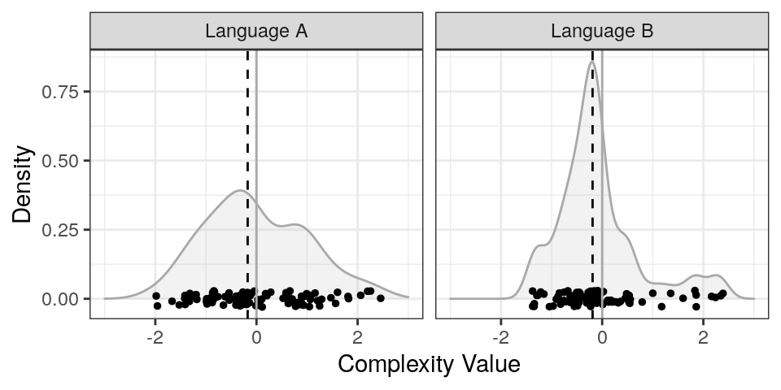

```r
density.plot <- ggplot(simulation.df.long, aes(x = value)) +
 geom_density(alpha = .2, fill = "grey", color = "darkgrey") +
 geom_jitter(data = simulation.df.long, aes(x = value, y = 0),
             size = 1, height = 0.03, width = 0) + # add some jitter to prevent overplotting
  geom_vline(aes(xintercept = 0), color = "darkgrey") +
  geom_vline(data = med, aes(xintercept = grp.median), linetype = "dashed") +
  facet_wrap(~ language) +
  xlim(-3, 3) +
  labs(x = "Complexity Value", y = "Density") +
  theme_bw() +
  theme(legend.position = "none")
print(density.plot)
```

## Scatterplot

Create a scatterplot to visualise the correlation.

[figure not shown]

```r
scatterplot <- ggplot(simulation.df.short, aes(x = langA, y = langB)) +
  geom_point(alpha = 0.3) +
  geom_smooth(method = loess, alpha = 0.3) +
  #geom_smooth(method = lm, alpha = 0.3) +
  ggtitle("b) Pearson r = - 0.8, Spearman rho = -0.76") +
  xlab("Complexity Value (Language A)") +
  ylab("Complexity Value (Language B)") +
  theme(legend.position = "none")
scatterplot
```

Safe figure to file.

```r
#ggsave("Figures/Simulation/scatterplot.pdf", density.plot, dpi = 300, scale = 1,
#       device = cairo_pdf)
```

## Normality

The assumption that the tested data stems from a normally distributed population is often necessary for the mathematical proofs underlying standard statistical techniques. We might apply normality tests to check for this assumption (e.g. Baayen 2008, p. 73), but some statisticians advice against such pre-tests, since they are often too sensitive (MacDonald 2014, p. 133-136, Rasch et al. (2020), p. 67). In fact, Rasch et al. (2020, p. xi) argue based on earlier simulation studies that almost all standard statistical tests are fairly robust against deviations from normality. However, it is still advisable to check for gross deviations from normality in the data. One common way of doing this is quantile-quantile plots. The points should here roughly follow a straight line (Crawley 2007, p. 281).

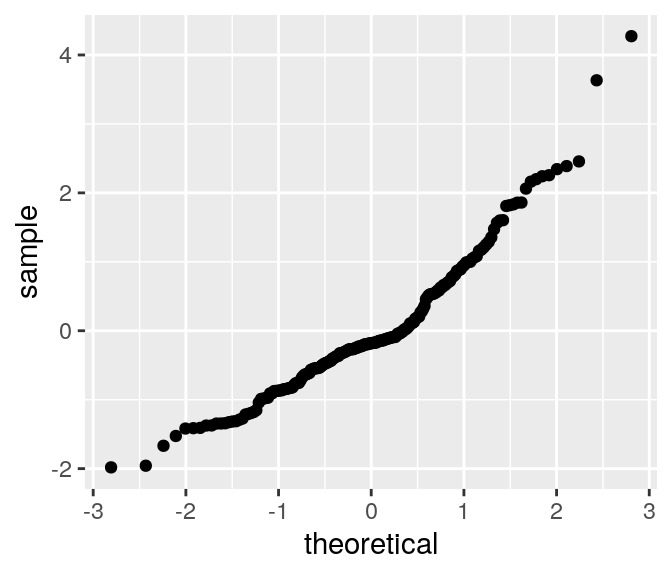

```r
ggplot(simulation.df.long, aes(sample = value)) +
  stat_qq()
```

## Choose statistical tests

Select a statistical test: Standard t-tests can be used to assess significant differences in the means of the pseudo-complexity distributions, if we assume that the underlying population distributions are normal. Wilcoxon tests are a non-parametric alternative, i.e. they do not make assumptions about the underlying population distribution, e.g. normality (Crawley 2007, p. 283; Baayen 2008, p. 77).

Run a t-test.

```r
t.test(simulation.df.short$langA, simulation.df.short$langB, paired = T)
```

```
##
##  Paired t-test
##
## data:  simulation.df.short$langA and simulation.df.short$langB
## t = -7.1453e-17, df = 99, p-value = 1
## alternative hypothesis: true difference in means is not equal to 0
## 95 percent confidence interval:
##  -0.3263074  0.3263074
## sample estimates:
## mean of the differences
##           -1.175058e-17
```

# References

Baayen, R. H. (2008). Analyzing linguistic data: A practical introduction using statistics in R. Cambridge University Press.

Cahusac, P. M. B. (2021). Evidence-based statistics. John Wiley & Sons.

Crawley, M. J. (2007). The R book. John Wiley & Sons Ltd.

Ehret, K. and B. Szmrecsanyi (2016). An information-theoretic approach to assess linguistic complexity. In: R. Baechler & G. Seiler (eds.), Complexity, Isolation, and Variation, 71-94. Berlin: de Gruyter.

Kruschke, J. K. (2012). Bayesian estimation supersedes the t test. Journal of Experimental Psychology.

McDonald, J.H. (2014). Handbook of Biological Statistics (3rd ed.). Sparky House Publishing, Baltimore, Maryland. online at http://www.biostathandbook.com

Patil, I. (2020). Test and effect size details. online at https://cran.r-project.org/web/packages/statsExpressions/vignettes/stats_details.html.

Rasch, D., Verdooren, R., and J. Pilz (2020). Applied statistics. Theory and problem solutions with R. John Wiley & Sons Ltd.